# Support Vector Machines (SVM)

Binary classification

Georgios P. Karagiannis @ MATH3431 Machine Learning and Neural Networks III

[Back to README](https://github.com/georgios-stats/Machine_Learning_and_Neural_Networks_III_Epiphany_2025/tree/main?tab=readme-ov-file#computer-lab-notes)

```r
rm(list=ls())
```

*Aim*

Students will become able to:

- practice in R,
- implement Support Vector Machine (classifiers) with R package **e1071** in R.

*Reading material*

- Lecture notes:
  - Lecture notes: Support Vector Machines
- References for the R package (optional supplementary material for your information)
  - [e1071 in R Cran](https://cran.r-project.org/web/packages/e1071/)
  - [e1071 Vignettes](https://cran.r-project.org/web/packages/e1071/vignettes/svmdoc.pdf)
  - [e1071 Vignettes](https://cran.r-project.org/web/packages/e1071/vignettes/svminternals.pdf)
- Reference for *R*:
  - [Cheat sheet with basic commands](https://cran.r-project.org/doc/contrib/Short-refcard.pdf)
- Reference of *rmarkdown* (optional, supplementary material):
  - [R Markdown cheatsheet](https://raw.githubusercontent.com/rstudio/cheatsheets/main/rmarkdown-2.0.pdf)
  - [R Markdown Reference Guide](https://www.rstudio.com/wp-content/uploads/2015/03/rmarkdown-reference.pdf)
  - [knitr options](https://yihui.name/knitr/options)
- Reference for *Latex* (optional, supplementary material):
  - [Latex Cheat Sheet](https://wch.github.io/latexsheet/latexsheet-a4.pdf)

*New software*

- R package **e1071** functions:
  - **svm{e1071}** : Used to train SVM.
  - **predict{e1071}**: Using this method, we obtain predictions from the model, as well as decision values from the binary classifiers.
  - **plot{e1071}** : Visualizing data, support vectors and decision boundaries, if provided.
  - **tune{e1071}** : Hyperparameter tuning uses tune() to perform a grid search over specified parameter ranges.

```r
# Load R package for printing
library(knitr)
```

```r
# Set a seed of the randon number generator
set.seed(2023)
```

# 1 Getting familiar with R package e1071

We will use the R package e1071 which is available from

- https://cran.r-project.org/web/packages/e1071/

The reference manual is available from

- https://cran.r-project.org/web/packages/e1071/e1071.pdf

Details

- **svm{e1071}** : Used to train SVM.
- **predict{e1071}**: Using this method, we obtain predictions from the model, as well as decision values from the binary classifiers.
- **plot{e1071}** : Visualizing data, support vectors and decision boundaries, if provided.
- **tune{e1071}** : Hyperparameter tuning uses tune() to perform a grid search over specified parameter ranges.

## 1.1 Install e1071

```r
## build version (recommended)
#install.packages("e1071")
## linux build
#install.packages("https://cran.r-project.org/src/contrib/e1071_1.7-14.tar.gz", repos = NULL, type = "source")
## windows build
#install.packages("https://cran.r-project.org/bin/windows/contrib/4.4/e1071_1.7-14.zip", repos = NULL, type = "source")
```

## 1.2 Load the R package e1071

```r
library(e1071)
```

# 2 Soft SVM

## 2.1 Load the data

Let’s load the available training dataset in and then plot.

```r
set.seed(1)
x <- matrix(rnorm(20 * 2), ncol = 2)
y <- c(rep(-1, 10), rep(1, 10))
x[y == 1, ] <- x[y == 1, ] + 1
```

In the plot below we see that they are not linearly separable, so a Soft SVM may be suitable to be used

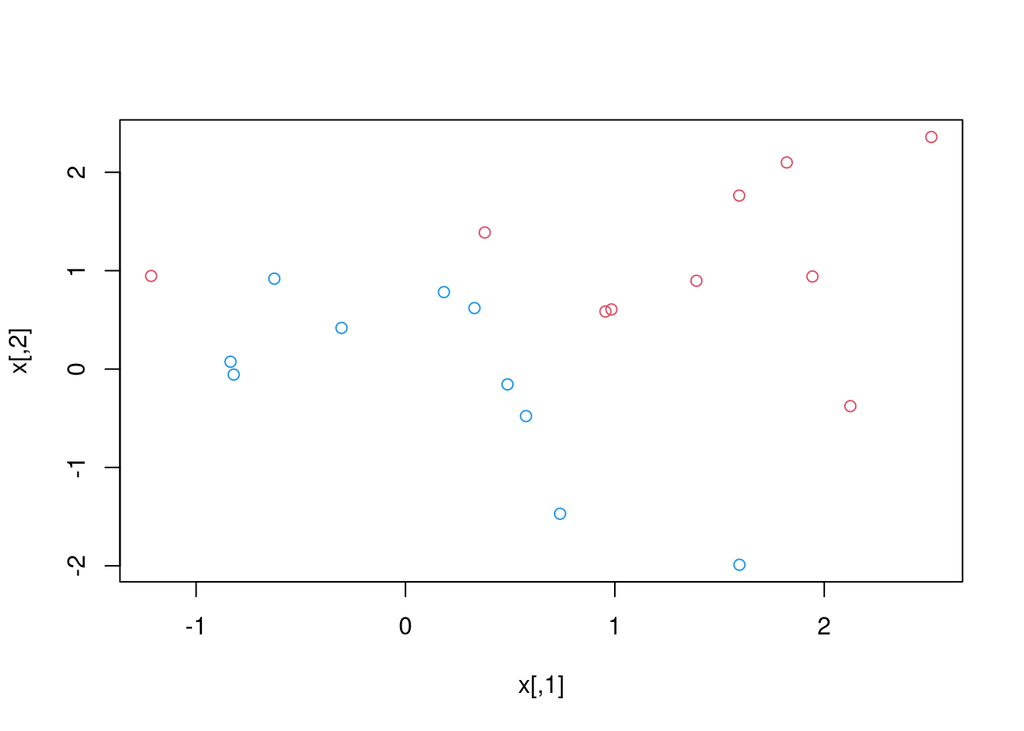

```r
plot(x, col = (3 - y))
```

To use the functions of R package **e1071**, we need to code the straining dataset as a data.frame as follows

```r
dat = data.frame(x, y = as.factor(y))
```

## 2.2 Fit the SVM classifier

To fit the SVM classifier use the R function **svm{e1071}**

Check R Documentation of **svm{e1071}** with **?svm** before you use it.

Here, use the arguments:

- **cost = 10** cost of constraints violation (default: 1)—it is the ‘C’-constant of the regularization term in the Lagrange formulation.
- **kernel = “linear”** the kernel used in training and predicting; the linear is $k(v,u)=<v,u>$.
- **scale = FALSE** to impose svm not to scale each feature to have mean zero or standard deviation one.

Save the output to an object with name **svmfit**

```r
svmfit <- svm(y ~ .,
              data = dat,
              kernel = "linear",
              cost = 10,
              scale = FALSE)
```

## 2.3 Print the summary of training

Use the R function **summary()** to print the basic information summary of the training.

Check in R documentation of “svm{e1071}”

- What type of svm did you actually use?
- What type of kernel of svm did you actually use?
- What is the numerical coding of the response?
- How many support vector did you use?

```r
summary(svmfit)
```

```
##
## Call:
## svm(formula = y ~ ., data = dat, kernel = "linear", cost = 10, scale = FALSE)
##
##
## Parameters:
##    SVM-Type:  C-classification
##  SVM-Kernel:  linear
##        cost:  10
##
## Number of Support Vectors:  7
##
##  ( 4 3 )
##
##
## Number of Classes:  2
##
## Levels:
##  -1 1
```

## 2.4 Plot the support vector classifier

Plot the support vector classifier obtained by using function **plot.svm {e1071}** .

Use it as **plot( my_obj , my_data )**

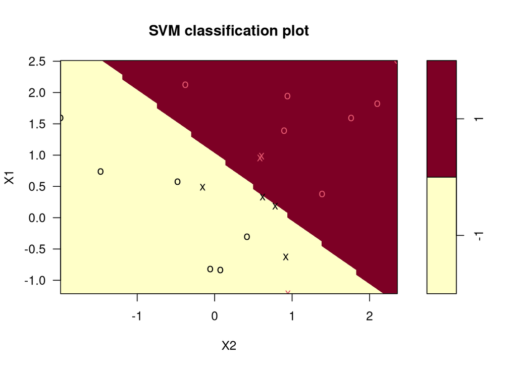

```r
plot(svmfit, dat)
```

In the plot:

- The region of feature space that will be assigned to the -1 class is shown in light yellow, and the region that will be assigned to the +1 class is shown in red.
- The points that are represented by an “X” are the support vectors, or the points that directly affect the classification line.
- The points marked with an “O” are the other points, which don’t affect the calculation of the line.
- The decision boundary between the two classes is linear (because of kernel = “linear”)

## 2.5 Investigate of the output produced by **svm {e1071}**

Have a look at the paragraph “Values” in the R documentation of **svm {e1071}**.

### 2.5.1 Get the support vectors

1. Print the resulting support vectors by using **svmfit$SV**, and double check with the previous plot.
2. Print the index of the resulting support vectors in the data matrix by using **svmfit$index**.

```r
# 1
print(svmfit$SV)
```

```
##            X1         X2
## 1  -0.6264538  0.9189774
## 2   0.1836433  0.7821363
## 5   0.3295078  0.6198257
## 7   0.4874291 -0.1557955
## 14 -1.2146999  0.9461950
## 16  0.9550664  0.5850054
## 17  0.9838097  0.6057100
```

```r
# 2
print(svmfit$index)
```

```
## [1]  1  2  5  7 14 16 17
```

### 2.5.2 Compute the linear coefficients $w$ and $b$.

Compute the coefficients $w=(w_1, w_2, ...)^\top$ and $b$ can be computed according to the theory by using the values

- **svm$coefs**: The corresponding coefficients times the training labels.
- **svm$index**: The index of the resulting support vectors in the data matrix.
- **svm$rho**: The negative intercept.

… for more details see the Section Values from R Dcoumentation of **svm {e1071}**.

Save the produced values of the coefficients $w=(w_1, w_2, ...)^\top$ as **w_est** and those of $b$ as **b_est** .

```r
X <- cbind(dat$X1,dat$X2)
w_est <- drop(t(svmfit$coefs)%*%X[svmfit$index,])
print(w_est)
```

```
## [1] -1.555547 -1.611534
```

```r
b_est <- svmfit$rho
print(b_est)
```

```
## [1] -1.506707
```

## 2.6 Make predictions (Optional task)

This is an optional tast; feel free to skip it

### 2.6.1 Recall: How to create a grid of points

As our feature space is 2 dimensional, it is practically feasible to create a grid of (input) points $x$ that covers the whole (input) domain on a fairly fine grid of points.

The following given R function returns a grid of points. (After the computer practical, feel free to check the routines used in this function.)

```r
make.grid = function(x, n = 75) {
  grange = apply(x, 2, range)
  x1 = seq(from = grange[1,1], to = grange[2,1], length = n)
  x2 = seq(from = grange[1,2], to = grange[2,2], length = n)
  expand.grid(X1 = x1, X2 = x2)
}
```

To test is, run the following, and understand that the grid goes through the 1st coordinate first, holding the 2nd coordinate fixed.

```r
# generate the grid of points
test_xgrid = make.grid(x, n = 10)
# print the grid of points
test_xgrid[1:10,]
```

|  | X1 | X2 |
| --- | --- | --- |
| 1 | -1.21469989 | -1.989352 |
| 2 | -0.80064644 | -1.989352 |
| 3 | -0.38659299 | -1.989352 |
| 4 | 0.02746046 | -1.989352 |
| 5 | 0.44151392 | -1.989352 |
| 6 | 0.85556737 | -1.989352 |
| 7 | 1.26962082 | -1.989352 |
| 8 | 1.68367427 | -1.989352 |
| 9 | 2.09772772 | -1.989352 |
| 10 | 2.51178117 | -1.989352 |

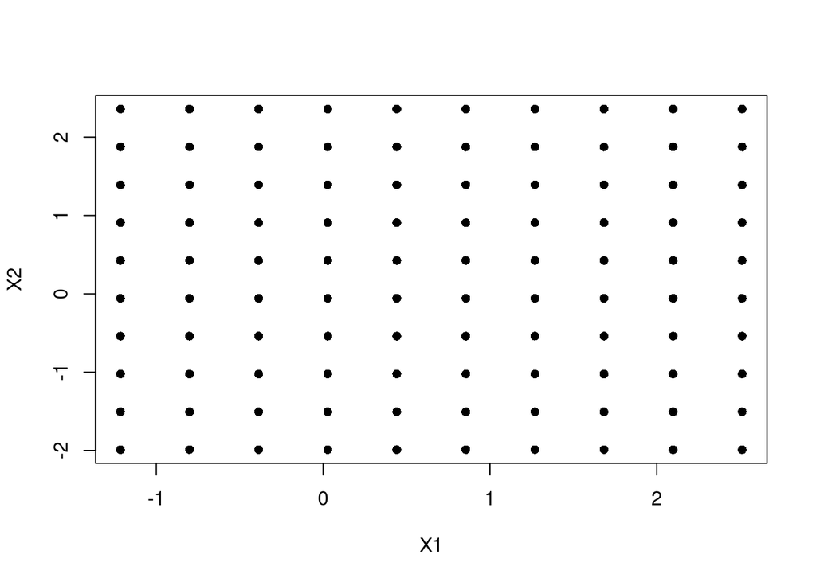

```r
# plot the grid of points
plot(test_xgrid,
     type = "p",
     pch = 16)
```

### 2.6.2 Do the predictions.

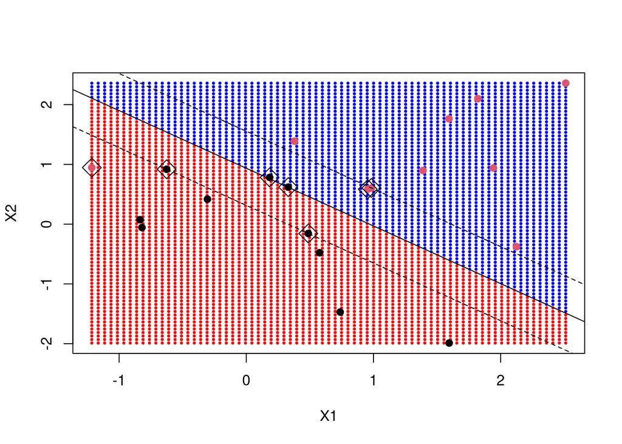

```r
# 1
x_new <- make.grid( x )
# 2
y_new <- predict( svmfit, x_new )
# 3
plot(x_new,
     col = c("red","blue")[as.numeric(y_new)],
     pch=20,
     cex=0.5)
# 4
points(dat$X1, dat$X2,
       col = as.numeric(dat$y),
       pch = 19)
# 5
points(dat$X1[svmfit$index],
       dat$X2[svmfit$index],
       pch = 5,
       cex = 2)
# 6
# I compute the coefficient estimates
w_est <- drop(t(svmfit$coefs)%*%x[svmfit$index,])
b_est <- svmfit$rho
# draw the hyperplanes
abline( b_est / w_est[2], -w_est[1] / w_est[2], lty = 1)
abline( (b_est-1) / w_est[2], -w_est[1] / w_est[2], lty = 2)
abline( (b_est+1) / w_est[2], -w_est[1] / w_est[2], lty = 2)
```

## 2.7 Inversigate the cost argument

Re-fit the SVM classifier with the R function **svm{e1071}** with argument **cost=0.1** (aka smaller than before).

Save the output returned by R function **svm()** as **svmfit**.

Plot the separator by using the function **plot()** from **plot.svm {e1071}**

Print the support vectors saved in **svmfit$index**.

What do you observe?

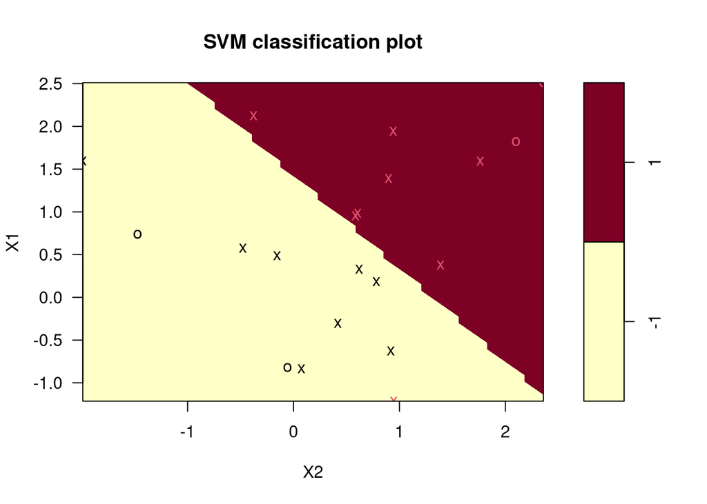

```r
svmfit <- svm(y ~ .,
              data = dat,
              kernel = "linear",
              cost = 0.1,
              scale = FALSE)
plot(svmfit, dat)
```

```r
svmfit$index
```

```
##  [1]  1  2  3  4  5  7  9 10 12 13 14 15 16 17 18 20
```

```r
# Now that a smaller value of the cost parameter is being used.
# We obtain a larger number of support vectors, because the margin is now wider.
# Unfortunately, the svm() function does not explicitly output the coefficients of
# the linear decision boundary obtained when the support vector classifier is fit,
# nor does it output the width of the margin.
```

## 2.8 Cross validation for tuning and model comparison

We investigate how to decide the value of cost **C** in an automatic manner.

Check R documentation of **tune{e1071}** by using **?tune** which will be used to perform cross-validation.

By default, **tune()** performs ten-fold cross-validation on a set of models of interest.

### 2.8.1 Choose a preferable value for the argument **cost**.

First we compare different parametrizations of svm clascifier each of them with different **cost** value. In particular the values 0.001, 0.01, 0.1, 1, 5, 10, and 100.

Use the function **tune()** with the arguments:

- **METHOD=svm** for using the svm methodology
- **kernel = “linear”** for the link “y~1 +x1 +x2” to be linear wrt the regressors.
- **ranges = list(cost = c(0.001, 0.01, 0.1, 1, 5, 10, 100))** to test over a range of cost values

Save the output in the object **tune.out** .

```r
set.seed(1) # for consistency reasons
tune.out <- tune(METHOD=svm,
                 y ~ ., data = dat,
                 kernel = "linear",
                 ranges = list(cost = c(0.001, 0.01, 0.1, 1, 5, 10, 100))
                 )
```

### 2.8.2 Print the summary

Use function **summary()** to print the results.

Which value is the preferable one, according to the error measure of comparison?

Double check with **tune.out$best.model** .

```r
summary(tune.out)
```

```
##
## Parameter tuning of 'svm':
##
## - sampling method: 10-fold cross validation
##
## - best parameters:
##  cost
##   0.1
##
## - best performance: 0.05
##
## - Detailed performance results:
##    cost error dispersion
## 1 1e-03  0.55  0.4377975
## 2 1e-02  0.55  0.4377975
## 3 1e-01  0.05  0.1581139
## 4 1e+00  0.15  0.2415229
## 5 5e+00  0.15  0.2415229
## 6 1e+01  0.15  0.2415229
## 7 1e+02  0.15  0.2415229
```

```r
#
#We see that cost = 0.1 results in the lowest cross-validation error rate.
```

```r
bestmod <- tune.out$best.model
summary(bestmod)
```

```
##
## Call:
## best.tune(METHOD = svm, train.x = y ~ ., data = dat, ranges = list(cost = c(0.001,
##     0.01, 0.1, 1, 5, 10, 100)), kernel = "linear")
##
##
## Parameters:
##    SVM-Type:  C-classification
##  SVM-Kernel:  linear
##        cost:  0.1
##
## Number of Support Vectors:  16
##
##  ( 8 8 )
##
##
## Number of Classes:  2
##
## Levels:
##  -1 1
```

### 2.8.3 Make predictions

The R function **predict()** from **predict.svm {e1071}** can be used to predict the class label on a set of test observations at any given value of the cost parameter.

Set **bestmod <- tune.out$best.model**

```r
bestmod <- tune.out$best.model
```

Consider the following new data set.

```r
xtest <- matrix(rnorm(20 * 2), ncol = 2)
ytest <- sample(c(-1, 1), 20, rep = TRUE)
xtest[ytest == 1, ] <- xtest[ytest == 1, ] + 1
testdat <- data.frame(xtest, y = as.factor(ytest))
```

1. Predict the class labels of these test observations.

   Use the best model obtained through cross-validation, aka **bestmod** in order to make predictions.

```r
ypred <- predict(bestmod, testdat)
```

2. Compute the SVM confusion matrix (miss-classification table)

   Use the R function **table()**.

How many correct classifications?

```r
table(predict = ypred, truth = testdat$y)
```

```
##        truth
## predict -1 1
##      -1  9 1
##      1   2 8
```

3. Compute how many correct classifications I can get with **cost = 0.01**.

   Use R function **svm** ; then **predict** ; then **table**.

```r
svmfit <- svm(y ~ ., data = dat, kernel = "linear",
    cost = .01, scale = FALSE)
ypred <- predict(svmfit, testdat)
table(predict = ypred, truth = testdat$y)
```

```
##        truth
## predict -1  1
##      -1 11  6
##      1   0  3
```

# 3 Soft SVM with non-linear kernels.

In order to fit an SVM using a non-linear kernel, we once again use the **svm()** function.

However, now we use a different value of the parameter `kernel`.

Function **svm{e1071}** can use a number of different kernel functions that can be found in the R Documentation (check ?svm, Argument kernel)

## 3.1 SVM with polynomial Kernel

Use the following dataset.

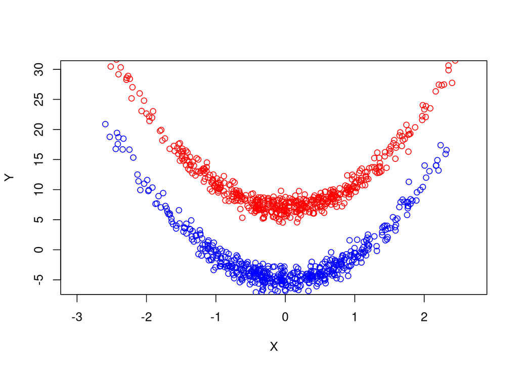

```
## integer(0)
```

```r
set.seed(1)
N = 1000
xx = rnorm(N)
yy = 4 * xx^2 + 1 + rnorm(N)
class = sample(N, N/2)
yy[class] = yy[class] + 6
yy[-class] = yy[-class] - 6
x <- cbind(xx,yy)
plot(x[class,1], x[class,2], col = "red", xlab = "X", ylab = "Y", ylim = c(-6, 30)) +
points(x[-class,1], x[-class,2], col = "blue")
```

```r
#
y = rep(-1, N)
y[class] = 1
data = data.frame(x, y = as.factor(y))
train = sample(N, N/2)
data_train = data[train, ]
data_eval = data[-train, ]
```

### 3.1.1 Fit Soft SVM with polynomial kernel.

To fit an SVM with a polynomial kernel we use **kernel = “polynomial”** (check in ?svm).

Have a look at the Section values in the R Documentation of **svm {e1071}**

The polynomial kernel is:

$$(\gamma u^\top v+c_0)^d$$

Fit the SVM classifier by using a polynomial kernel of degree $d=2$. In particular, use arguments

```r
svmfit <- svm(y ~ .,
              data = data_train,
              kernel = "polynomial",
              degree = 2,
              gamma = 1,
              coef0 = 0,
              cost = 1,
              scale = FALSE)
```

### 3.1.2 Plot the separator

Plot the result by using the function **plot** from **plot.svm {e1071}**

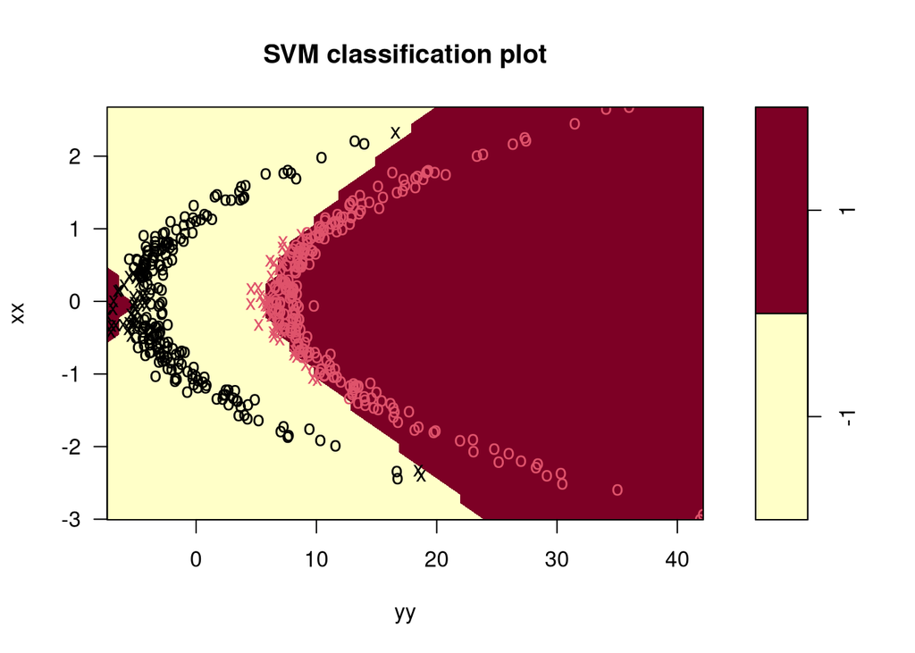

```r
plot(svmfit, data_train)
```

### 3.1.3 Perform Cross Validation to tune

Choose appropriate values for the parameters of the polynomial kernel in the following ranges

- **cost = c(0.01, 0.05, 0.1)**
- **gamma = c(0.5,1,2.0)**
- **coef0 = c(0,1,2)**
- **degree = c(1,2,3)**

Use the function **tune()** from **tune {e1071}** .

Print the results with function **summary()**.

Which parametrization is preferable?

```r
set.seed(1)
tune.out <- tune(svm, y ~ ., data = data_train,
    kernel = "polynomial",
    ranges = list(
      cost = c(0.01, 0.05, 0.1),
      gamma = c(0.5,1,2.0),
      coef0 = c(0,1,2),
      degree = c(1,2,3)
    )
  )
summary(tune.out)
```

```
##
## Parameter tuning of 'svm':
##
## - sampling method: 10-fold cross validation
##
## - best parameters:
##  cost gamma coef0 degree
##  0.05   0.5     1      2
##
## - best performance: 0
##
## - Detailed performance results:
##    cost gamma coef0 degree error  dispersion
## 1  0.01   0.5     0      1 0.048 0.028596814
## 2  0.05   0.5     0      1 0.064 0.027968236
```

[output cut: 79 more lines]

## 3.2 SVM with radial Kernel

We use the following training data set.

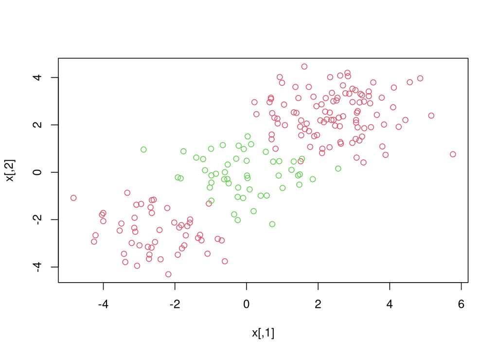

```r
x <- matrix(rnorm(200*2), ncol = 2)
x[1:100,] <- x[1:100,] + 2.5
x[101:150,] <- x[101:150,] - 2.5
y <- c(rep(1,150), rep(2,50))
dat <- data.frame(x,y=as.factor(y))
plot(x, col = y + 1)
```

### 3.2.1 Fit Soft SVM with radial Kernel

To fit an SVM with a radial kernel we use kernel = “radial” (check by ?svm).

In Particular the radial kernel is coded as:

$$\exp(-\gamma |v-v'|_2^2)$$

So we can use the arguments

- **gamma**, for $\gamma$

Fit the SVM classifier by using a radial kernel with parameter $\gamma=1/2$.

```r
svmfit <- svm( factor(y) ~ .,
            data = dat,
            scale = FALSE,
            kernel = "radial",
            gamma = 1/2,
            cost = 10)
```

### 3.2.2 Plot the separator

Plot the result by using the function **plot** from **plot.svm {e1071}**

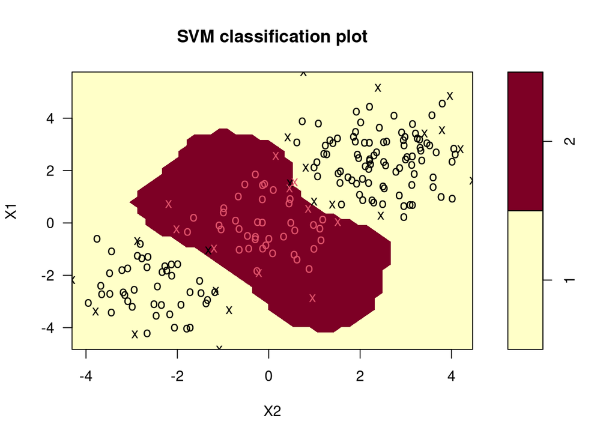

```r
plot(svmfit, dat)
```